# 4. Preprocesamiento de los datos

En este notebook se va a llevar a cabo la última parte del preprocesamiento de los datos, estos son los pasos que vamos a seguir siguiendo:

1. Feature engineering a. Variables categoricas a numericas: one hot encoding b. PCA c. clusterización: K-means
2. Seleccion de variables a. Lasso / Ridge (peso de las variables en regresión lineal)
3. Undersampling / oversampling (train)

## **Librerías**

```python
import pandas as pd
import numpy as np
import sklearn
import matplotlib.pyplot as plt
import seaborn as sns
import category_encoders as ce

from sklearn.pipeline import Pipeline
from sklearn import metrics
from sklearn.preprocessing import OneHotEncoder
from sklearn.ensemble import GradientBoostingClassifier
from sklearn.ensemble import RandomForestClassifier, AdaBoostClassifier
from sklearn.preprocessing import StandardScaler
from sklearn.metrics import classification_report, confusion_matrix, roc_curve, auc, \
                            silhouette_score, recall_score, precision_score, make_scorer, \
                            roc_auc_score, f1_score, precision_recall_curve, accuracy_score, roc_auc_score, \
                            classification_report, confusion_matrix
from sklearn import metrics
from sklearn.metrics import *
from funciones_fraud import *
from sklearn.decomposition import PCA
from sklearn.cluster import KMeans
from sklearn.cluster import DBSCAN
from sklearn.feature_selection import SelectFromModel
from sklearn.linear_model import LogisticRegression
from sklearn.preprocessing import StandardScaler
from sklearn.model_selection import train_test_split

import warnings
warnings.filterwarnings("ignore")
```

## **Lectura de datos del preprocesado inicial**

```python
path_folder = "./"
df_train = pd.read_csv(path_folder +"train0_data.csv", low_memory=False)
df_test = pd.read_csv(path_folder +"test_data.csv", low_memory=False)
```

```python
print(df_train.shape, df_test.shape)
```

```
(800000, 32) (200000, 32)
```

## Feature engineering

### Codificación de la variable objetivo

```python
df_train['fraud_bool'].value_counts()
```

```
fraud_bool
0    791195
1      8805
Name: count, dtype: int64
```

Como en el dataset, la variable target _fraud*bool*, ya viene transformada entre 0 y 1. No hace falta transformarla, en el siguiente paso estamos quitando del conjunto x la variables fraud_bool, y la variable y va a ser nuestra variable objetivo, en este caso _fraud*bool*

```python
X_train = df_train.drop('fraud_bool',axis=1)
y_train = df_train['fraud_bool']
X_test = df_test.drop('fraud_bool',axis=1)
y_test = df_test['fraud_bool']
print(X_train.shape, X_test.shape)
```

```
(800000, 31) (200000, 31)
```

### Creación de nuevas variables

Creamos nuevas variables tanto en el conjunto de train0 como en el de test:

```python
umbral_similaridad = 0.10
X_train['address_months_total'] = X_train['prev_address_months_count'] + X_train['current_address_months_count']
X_train['email_similarity_binary'] = (X_train['name_email_similarity'] > umbral_similaridad).astype(int)
X_train['income_times_age'] = X_train['income'] * X_train['customer_age']

X_test['address_months_total'] = X_train['prev_address_months_count'] + X_train['current_address_months_count']
X_test['email_similarity_binary'] = (X_train['name_email_similarity'] > umbral_similaridad).astype(int)
X_test['income_times_age'] = X_train['income'] * X_train['customer_age']
```

```python
print(X_train.shape, X_test.shape)
```

```
(800000, 34) (200000, 34)
```

Hemos creado un total de tres nuevas variables:

1. Primero hemos relacionado las variables que tienen en cuenta el número de meses que llevan registrados sus antiguos y nuevos domicilios. Hemos creido conveniente crear una nueva variable que nos indique el total de las dos. Con esta información podemos saber cuánto tiempo tenemos registrada la vivienda del solicitante. La variable en cuestión, la hemos llamado **address_months_total**.
2. Una de nuestras variables es 'name_email_similarity' que nos dice cuanto de parecidos son el nombre y el email correspondiente del solicitante. Hemos querido observar el número de solicitantes que menor porcentaje tuvieran, ya que resulta sospechoso que tu correo electrónico no tenga similitud con el nombre del cliente. El valor 0 serán los solicitantes con menos de un 0.10 de similitud, hemos escogido este valor porque esta un poquito por debajo que la media. El nombre de la misma es **email_similarity_binary**.
3. Por último, hemos querido relacionar la edad, con el income que tiene los solicitantes. Creemos que puede ser interesante como se comporta y ver si puede llegar a ser útil dentro de nuestro análisis. Hemos visto que las personas mayores y con más income tienden a ser más fraudulentas por lo que creemos que puede ser interesante este nuevo atributo llamado **income_times_age**.

### Codificación del resto de variables categóricas

"One Hot Encoding es una estrategia que consiste en crear una columna binaria (que solo puede contener los valores 0 o 1) para cada valor único que exista en la variable categórica que estamos codificando, y marcar con un 1 la columna correspondiente al valor presente en cada registro, dejando las demás columnas con un valor de 0."(https://interactivechaos.com/es/manual/tutorial-de-machine-learning/one-hot-encoding)

En este caso hemos decidido utilizar este método para codificar las variables categóricas de nuestra dataset, esto nos facilitará a la hora de analizar y de aplicar los diferenetes modelos. Para ello vamos a diferenciar nuestro dataset en variables categoricas, que en el notebook 2 previamente habíamos analizado.

```python
columnas_categoricas, columnas_continuas = categorizar_columnas(df_train)
```

```
Conteo de valores para 'payment_type':
payment_type
AB    296135
AA    206641
AC    201863
AD     95135
AE       226
Name: count, dtype: int64


Conteo de valores para 'employment_status':
employment_status
CA    584188
CB    110459
CF     35297
CC     30252
CD     21224
CE     18227
CG       353
Name: count, dtype: int64


Conteo de valores para 'housing_status':
housing_status
BC    297793
BB    209055
BA    135451
BE    135337
BD     20839
BF      1325
BG       200
Name: count, dtype: int64


Conteo de valores para 'source':
source
INTERNET    794336
TELEAPP       5664
Name: count, dtype: int64


Conteo de valores para 'device_os':
device_os
other        274058
linux        266078
windows      210902
macintosh     43160
x11            5802
Name: count, dtype: int64
```

```python
from sklearn.preprocessing import OneHotEncoder
ohe = OneHotEncoder()
model = ohe.fit(X_train.loc[:,columnas_categoricas])
```

```python
model
```

```
OneHotEncoder()
```

```python
X_train_t = model.transform(X_train.loc[:,columnas_categoricas]).toarray()
X_test_t = model.transform(X_test.loc[:,columnas_categoricas]).toarray()
```

```python
model.get_feature_names_out(columnas_categoricas)
```

```
array(['payment_type_AA', 'payment_type_AB', 'payment_type_AC',
       'payment_type_AD', 'payment_type_AE', 'employment_status_CA',
       'employment_status_CB', 'employment_status_CC',
       'employment_status_CD', 'employment_status_CE',
       'employment_status_CF', 'employment_status_CG',
       'housing_status_BA', 'housing_status_BB', 'housing_status_BC',
       'housing_status_BD', 'housing_status_BE', 'housing_status_BF',
       'housing_status_BG', 'source_INTERNET', 'source_TELEAPP',
       'device_os_linux', 'device_os_macintosh', 'device_os_other',
       'device_os_windows', 'device_os_x11'], dtype=object)
```

Ahora juntaremos las columnas anteriomente categoricas que hemos convertido a numericas gracias al OneHotEncoder, con el resto de las variables que ya eran numéricas dentro del dataset.

```python
remaining_columns_train = [col for col in X_train.columns if col not in columnas_categoricas]
remaining_columns_test = [col for col in X_test.columns if col not in columnas_categoricas]
```

```python
X_train_cat = pd.DataFrame(X_train_t, columns=model.get_feature_names_out(columnas_categoricas))
X_test_cat = pd.DataFrame(X_test_t, columns=model.get_feature_names_out(columnas_categoricas))
```

```python
X_train_t = pd.concat([X_train_cat, X_train[remaining_columns_train]], axis=1)
X_test_t = pd.concat([X_test_cat, X_test[remaining_columns_test]], axis=1)
```

Podemos observar que tanto en el conjunto de datos X_train_t como en el X_test_t ya aparecen todas las variables.

```python
column_names = X_train_t.columns
```

```python
print(X_train_t.shape, X_test_t.shape)
```

```
(800000, 55) (200000, 55)
```

A consecuencia de haber usado el OneHotEncoder hemos pasado de tener 34 atributos a contar con un total de 55, incluido las variables que hemos añadido las que tenemos que quitar.

### Escalado de variables

Hemos optado por realizar el escalado de nuestras variables, ya que creemos que puede influir en algunos modelos, como el PCA. La omisión de este proceso podría sesgar el PCA hacia características de magnitud alta, dado que busca obtener aquellas con la máxima varianza, y esta suele ser elevada en variables de gran magnitud. Nos hemos decantado a través de la estandarización de variables. Este proceso consiste en estandarizar la media y hacer que la desviación típica sea la misma en todas las variables. Hemos obtenido esta información en el artículo escrito por Sudharsan Asaithambi (https://medium.com/greyatom/why-how-and-when-to-scale-your-features-4b30ab09db5e)

```python
pd.set_option('display.max_columns', None)
```

```python
scaler = StandardScaler()
model_scaled = scaler.fit(X_train_t)
X_train_scaled = pd.DataFrame(scaler.transform(X_train_t), columns=X_train_t.columns, index=X_train_t.index)
X_test_scaled = pd.DataFrame(scaler.transform(X_test_t), columns=X_test_t.columns, index=X_test_t.index)
```

### Reducir dimensionalidad de filas

Este algoritmos nos va ayudar a reducir la dimensionalidad de las filas de nuestra base de datos. Se basa en un proceso de optimización iterativo. Vamos a llevarlo a cabo creando un nuevo atributo que indique a que cluster pertenece cada instancia. Esto nos ayudará más adelante a observar patrones.

#### PCA

```python
scaler = StandardScaler()
features_standardized = scaler.fit_transform(X_train_scaled)
n = len(X_train_scaled)
```

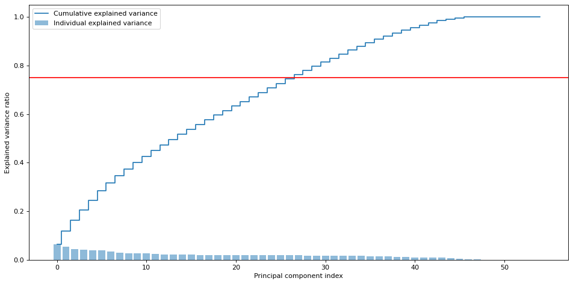

```python
pca = PCA()
pca.fit(X_train_scaled)
exp_var_pca = pca.explained_variance_ratio_

cum_sum_eigenvalues = np.cumsum(exp_var_pca)
threshold = 0.75
plt.figure(figsize=(12, 6), dpi=80)

x_ticks = np.arange(0, len(exp_var_pca), 10)
plt.bar(range(0, len(exp_var_pca)), exp_var_pca, alpha=0.5, align='center', label='Individual explained variance')
plt.step(range(0, len(cum_sum_eigenvalues)), cum_sum_eigenvalues, where='mid', label='Cumulative explained variance')
plt.axhline(y=threshold, color='r', linestyle='-')

plt.ylabel('Explained variance ratio')
plt.xlabel('Principal component index')
plt.xticks(x_ticks)
plt.legend(loc='best')
plt.tight_layout()
plt.show()
```

```python
pca = PCA(n_components=2)
features_2D = pca.fit_transform(features_standardized)
```

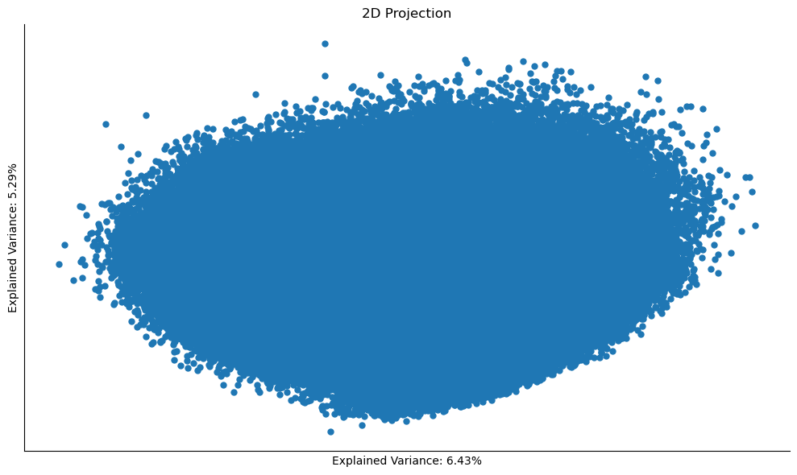

```python
ev1, ev2 = pca.explained_variance_ratio_

cmap = 'viridis'

fig, ax = plt.subplots(figsize=(10, 6))

ax.set_title('2D Projection')
ax.set_xlabel(f'Explained Variance: {ev1:.2%}')
ax.set_ylabel(f'Explained Variance: {ev2:.2%}')

ax.scatter(*features_2D.T, s=25, cmap=cmap)

ax.set_xticklabels([])
ax.set_xticks([])
ax.set_yticklabels([])
ax.set_yticks([])

sns.despine()

plt.tight_layout()
plt.show()
```

#### K-means

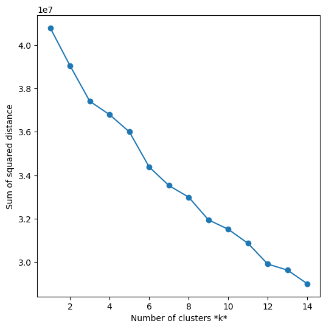

```python
sse = []
list_k = list(range(1, 15))

for k in list_k:
    km = KMeans(n_clusters=k)
    km.fit(X_train_scaled)
    sse.append(km.inertia_)

# Plot sse against k
plt.figure(figsize=(6, 6))
plt.plot(list_k, sse, '-o')
plt.xlabel(r'Number of clusters *k*')
plt.ylabel('Sum of squared distance');
```

Como se puede observar este gráficos de codo no llega a hacer un cambio drástico que forme un codo, hemos decidido coger el hasta 12 clusters ya que observarmos una pequeña figura de codo

```python
k_clf = KMeans(n_clusters = 12, random_state = 0)
k_clf.fit(X_train_scaled)
pd_final_cluster = pd.DataFrame(k_clf.predict(X_train_scaled), index=X_train_scaled.index)
pd_final_cluster.columns = ['cluster']
pd_data_train = pd.concat([pd_final_cluster, X_train_scaled],axis=1)
```

```python
k_clf = KMeans(n_clusters = 12, random_state = 0)
k_clf.fit(X_test_scaled)
pd_final_cluster = pd.DataFrame(k_clf.predict(X_test_scaled), index=X_test_scaled.index)
pd_final_cluster.columns = ['cluster']
pd_data_test = pd.concat([pd_final_cluster, X_test_scaled],axis=1)
```

```python
pd_data_train['cluster'].value_counts()
```

```
cluster
5     121392
2     118364
3     117188
4     105844
7      93327
1      91155
9      57410
8      54176
11     29481
10      5775
0       5662
6        226
Name: count, dtype: int64
```

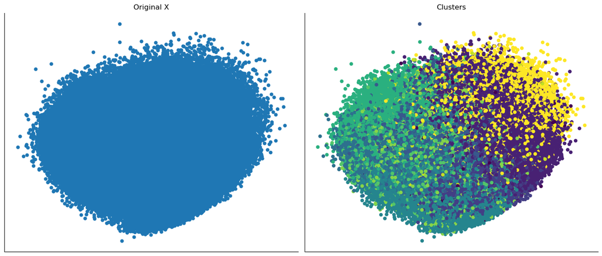

```python
fig, axes = plt.subplots(ncols=2,
                         figsize=(14, 6))

clusters = pd_data_train['cluster']


axes[0].scatter(*features_2D.T, s=25, cmap=cmap)
axes[0].set_title('Original X')
axes[1].scatter(*features_2D.T, c=clusters, s=25, cmap=cmap)
axes[1].set_title('Clusters')

for ax in axes:
    ax.axes.get_xaxis().set_visible(False)
    ax.axes.get_yaxis().set_visible(False)
sns.despine()
fig.tight_layout()
```

En estos dos gráficos podemos observar como ha creado los clusters teniendo en cuenta la posición de todos los registros. Ha tenido que buscar un centroide para cada uno de ellos. Es cierto que al ser un gran número de registros no se percibe muy bien que registro pertenece a cada cluster. Otra dificultad añadida es que los registros estan muy concentrados en un lugar concreto por lo que es dificil crear clusters.

```python
X_train = pd_data_train
X_test = pd_data_test
```

## Selección de variables

```python
sel_ridge = SelectFromModel(LogisticRegression(C=1, penalty='l2'), threshold = 0.09)
sel_ridge.fit(X_train, y_train)
```

```
SelectFromModel(estimator=LogisticRegression(C=1), threshold=0.09)
```

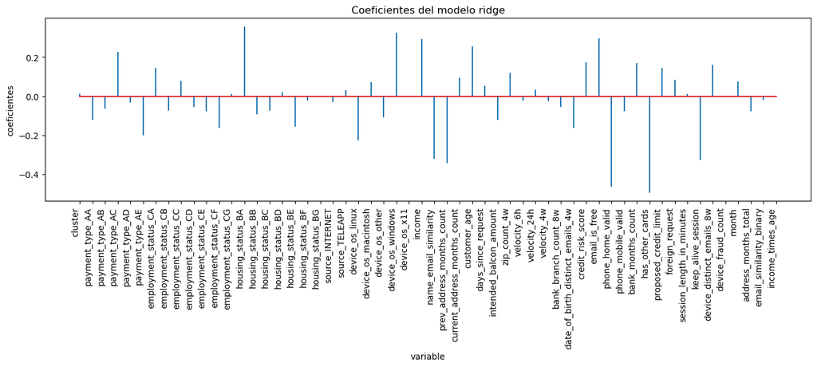

```python
df_coeficientes = pd.DataFrame(
                        {'predictor': X_train.columns,
                         'coef': sel_ridge.estimator_.coef_.flatten()}
                  )

fig, ax = plt.subplots(figsize=(16, 3.84))
ax.stem(df_coeficientes.predictor, df_coeficientes.coef, markerfmt=' ')
plt.xticks(rotation=90, ha='right', size=10)
ax.set_xlabel('variable')
ax.set_ylabel('coeficientes')
ax.set_title('Coeficientes del modelo ridge');
```

```python
sel_ridge.get_support()
selected_feat = X_train.columns[sel_ridge.get_support()]
selected_feat
```

```
Index(['payment_type_AA', 'payment_type_AC', 'payment_type_AE',
       'employment_status_CA', 'employment_status_CF', 'housing_status_BA',
       'housing_status_BB', 'housing_status_BE', 'device_os_linux',
       'device_os_other', 'device_os_windows', 'income',
       'name_email_similarity', 'prev_address_months_count',
       'current_address_months_count', 'customer_age',
       'intended_balcon_amount', 'zip_count_4w',
       'date_of_birth_distinct_emails_4w', 'credit_risk_score',
       'email_is_free', 'phone_home_valid', 'bank_months_count',
       'has_other_cards', 'proposed_credit_limit', 'keep_alive_session',
       'device_distinct_emails_8w'],
      dtype='object')
```

```python
print('total features: {}'.format((X_train.shape[1])))
print('selected features: {}'.format(len(selected_feat)))
```

```
total features: 56
selected features: 27
```

La regularización Ridge penaliza la suma de los coeficientes estimados elevados al cuadrado A esta penalización se le conoce como l2 y tiene el efecto de reducir de forma proporcional el valor de todos los coeficientes del modelo pero sin que estos lleguen a cero. El grado de penalización está controlado por el hiperparámetro λ . Cuando λ=0 , la penalización es nula y el resultado es equivalente al de un modelo lineal por mínimos cuadrados ordinarios (OLS). A medida que λ aumenta, mayor es la penalización y menor el valor de los predictores.

Esto significa que nos quedamos con 27 de 56 atributos que teníamos dentro del datset. Este modelo nos permite mediante Regresión logística seleccionar las variables que tengan más importancia dentro del modelo.

No vamos a utilizar las selected features vamos a quitar las que estan repetidas al haber creado nuevas variables.

```python
columnas_a_eliminar = ['prev_address_months_count', 'current_address_months_count','name_email_similarity','income','customer_age','device_fraud_count']
X_train = X_train.drop(columns=columnas_a_eliminar)
X_test = X_test.drop(columns=columnas_a_eliminar)
```

```python
print(X_train.shape, X_test.shape)
```

```
(800000, 50) (200000, 50)
```

```python
X_train1, X_val, y_train1, y_val = train_test_split(X_train, y_train, test_size=0.2, random_state=42)

print("Tamaño del conjunto de entrenamiento1", len(X_train1))
print("Tamaño del conjunto de validación:", len(X_val))
```

```
Tamaño del conjunto de entrenamiento1 640000
Tamaño del conjunto de validación: 160000
```

### Undersampling

A continuación, vamos a tratar la variable dependiente, en este caso _fraud*bool* ya que es una variable cuyos datos se encuentran desbalanceados. Vamos a llevar a cabo un proceso de undersampling en vez de oversampling, con el fin de utilizar librería en python y obtener la misma representatividad. El undersampling significa reducir el número de registros de la clase mayoritaria (la clase con más ejemplos), en nuestro caso _fraud*bool*=0, para equilibrar la proporción entre las clases.

```python
from imblearn.under_sampling import RandomUnderSampler
from collections import Counter
```

```python
rus = RandomUnderSampler(random_state=0)
X_train_c, y_train_c = rus.fit_resample(X_train, y_train)
```

```python
print(sorted(Counter(y_train_c).items()))
```

```
[(0, 8805), (1, 8805)]
```

```python
rus = RandomUnderSampler(random_state=0)
X_train_u, y_train_u = rus.fit_resample(X_train1, y_train1)
```

```python
print(sorted(Counter(y_train_u).items()))
```

```
[(0, 7105), (1, 7105)]
```

```python
X_train_c.to_csv('Xtrain0_data.csv', index=False, header=True)
y_train_c.to_csv('ytrain0_data.csv', index=False, header=True)
X_train_u.to_csv('Xtrain1_data.csv', index=False, header=True)
y_train_u.to_csv('ytrain1_data.csv', index=False, header=True)
X_test.to_csv('Xtest_data.csv', index=False, header=True)
y_test.to_csv('ytest_data.csv', index=False, header=True)
X_val.to_csv('Xval_data.csv', index=False, header=True)
y_val.to_csv('yval_data.csv', index=False, header=True)
```

```python
print(X_train_c.shape, y_train_c.shape)
```

```
(17610, 50) (17610,)
```

```python
print(X_test.shape, y_test.shape)
```

```
(200000, 50) (200000,)
```

```python
print(X_train_u.shape, y_train_u.shape)
```

```
(14210, 50) (14210,)
```

```python
print(X_val.shape, y_val.shape)
```

```
(160000, 50) (160000,)
```

Con esto conseguimos balancear los datos de la variable objetivo, _fraud*bool*, haciendo que el porcentaje de registros de los 0 y los 1 sea el mismo.